# Classification of Chest/Abdominal X-Rays via CNN

Eduardo Coronado

5/13/2019

*Example and code based on:*  
Lakhani, Paras, et al. **“Hello world deep learning in medical imaging.”** *Journal of digital imaging* 31.3 (2018): 283-289.

### I. Building the Model

#### Initial Steps

Before building a Convolutional Neural Network we must first specify a couple of parameters such as our image sizes, the number of images to be processed at a time (`batch`), and number of passes through training data (`epochs`). Additionally, we need to specify the location of our data directory. Later we will divide these into training and test sets.

```r
# Image dimensions in pixels
img_width = img_height <- 299

# Data director, it has two subfolders (i.e. chest and abdomen)
all_dat_dir <- file.path(data_dir, "ALL_DAT")

# List number of samples via list.files() fcn
# use recursive = TRUE to go into subfulders
all_samples <- length(list.files(all_dat_dir, recursive = TRUE))

#epochs = number of passes through training data
# batch_size = number images processed at same time
epochs <- 20L
batch_size <- 5
```

Given the accuracy of a CNN depends heavily on the amount of data it has been trained on, we will use the Inception V3 model as our base model (this is pre-loaded in `keras`). Given we only have small image data set, we can take advantage of Inception V3’s previoulsy optimized/trained weights g on a large image data set (`imagenet`).

```r
# Inception V3 CNN input shape must be (299, 299, 3)
in_shape <- c(img_width, img_height, 3)

# build the Inception V3 CNN model with pre-trained weights from ImageNet
# and remove top fully connected layers by with include_top=False
base_model <- application_inception_v3(include_top = FALSE, weights='imagenet',
                                      input_shape = in_shape)
```

#### Transfer Learning and Adding Randomized Layers

Although, the Inception V3 model was trained to classify color images with over 1,000 classes we can still use the basic framework for X-Ray classification. In other words, we’re implementing **Transfer Learning** (i.e. using pre-trained network as a base).  
For example, we first remove Inception V3’s top fully connected layers that was originally intended to address the 1,000-class problem (*freezing layers*). Then, we add some randomized layers and train them with our data on top of the pre-trained structure at a slow learning rate.

(*Note*: There are many other transfer learning strategies other than the one depicted above)

```r
# build a classifier model to place on top of the Inception V3 model
# This layer includes a global average pooling layer and a fully connected layer with 256 nodes
# with a dropout layer and sigmoid activation for output
model_top <- keras_model_sequential()
model_top %>% unlist(base_model$output_shape[2:4]) %>%
  layer_global_average_pooling_2d(data_format= NULL, trainable = TRUE) %>%
  layer_dense(units = 256, activation = "relu", trainable = TRUE ) %>%
  layer_dropout(rate = 0.5, trainable = TRUE ) %>%
  layer_dense(units = 1, activation = "sigmoid", trainable = TRUE)

model <- keras_model(inputs = base_model$input, outputs = model_top(base_model$output))
```

After adding this top layer to the Inception V3 model, we compile it using the built-in Adam optimizer (`optimizer_adam`). There are many other gradient descent optimizers in `keras` but here we will use Adam as an example with commonly used settings. However, we reduced the learning rate (`lr`) to allow for transfer learning as shown below.

```r
# Compile model using Adam optimizer with common values and binary cross entropy loss
# since we are only looking at two classes (chest and abdominal)
# We use a low learning rate (lr) for transfer learning
model %>% compile(optimizer = optimizer_adam(lr=0.0001,
                                             beta_1=0.9,
                                             beta_2=0.999,
                                             epsilon=1e-08, decay=0.0),
                  loss = "binary_crossentropy",
                  metrics= "accuracy")

# Uncomment line below if you want to review model layers, outputs and parameters
#summary(model)
```

### II) Image Preprocessing and Augmentation

To avoid overfitting based on the training data we use some image augmentation techniques such as rotations, translations, zooming, shearing, and flipping. `keras` has a built-in `image_data_generator` function that can perform these augmentations “on-the-fly” or “on-the-go”. Additionally, given we will want to evaluate how well our model performs we can split our images into train and validation sets. This can be done via the `validation_split` parameter that allows us to specify the amount of data to set aside as test data.

After defining the data augementation procedures, we then create train and test objects that will grab the images from a specified directory (`flow_images_from_directory`), perform these augmentations on the images and present them to the model in batches.

```r
# Data augmentation options via the keras image_data_generator

# Preprocess - Largest pixel value is 255, thus x/255 rescales values between 0-1
# On-the-fly augmentation options for generator
datagen <- image_data_generator(rescale = 1/255, # Rescale pixel values to 0-1 to help CNN
                                      shear_range = 0.2, # 0-1 range for shearing
                                      zoom_range = 0.2, # 0-1 range for zoom
                                      rotation_range = 20, # 0-180 range for rotation
                                      width_shift_range = 0.2, # 0-1 range horizontal translation
                                      height_shift_range = 0.2, # 0-1 range vertical translation
                                      horizontal_flip = TRUE,
                                validation_split = 0.15 # set aside 15% of images as test set
                                )



# Specify data directory, batch size, image sizes and class mode to be passed
# into generator
# Class mode is set to 'binary' for our 2-class problem
# This generator will randomly shuffle and present images in batches to the network
train_generator <- flow_images_from_directory(directory = all_dat_dir,
                                              generator = datagen,
                                              target_size = c(img_height, img_width),
                                              batch_size = batch_size,
                                              class_mode = "binary", seed = 1,
                                              subset = "training" ) # use training subset


test_generator <- flow_images_from_directory(directory = all_dat_dir,
                                             generator = datagen,
                                             target_size = c(img_height, img_width),
                                             batch_size = batch_size,
                                             class_mode = "binary", seed = 1,
                                             subset = "validation") # use test subset
```

### III) Model Training

After defining the train and test generators we will now train the model using the `fit_generator` function and storing it in the history (`hist`) variable. This takes in the training and test images, the number of epochs we wish the model to learn from, and the steps per epoch (i.e. number of images/batch size). For each epoch, the cross-entropy loss and accuracy are computed for the training and test (validation) data. Here, the training time depends on computing power (CPUs, RAM memory, GPUs, etc), number of epochs and steps per epoch. For example, it takes about 10 minutes to train this model using a Mac OS with 16 Gb RAM and 2-4 CPUs.

```r
# Use training data plus data generator to fine-tune pre-trained Inception V3 model
# Specify steps per epoch (number of images/batch_size)
hist <- model %>%
  fit_generator(train_generator,
                steps_per_epoch = as.integer((all_samples*.85)/batch_size),
                epochs = epochs,
                validation_data = test_generator,
                validation_steps = as.integer((all_samples*.15)/batch_size),
                verbose = 1 # verbose = 2, one line per epoch
                )
```

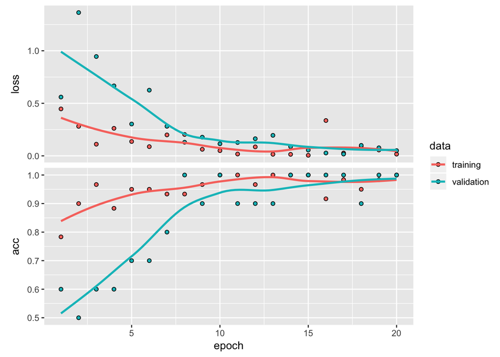

```r
#Save accuracy/loss metrics as dataframe
hist_df <- hist$metrics %>% as_data_frame()

# Use generic plot function to plot accuracy/loss metrics in ggplot
plot(hist)
```